# Practice Project - FIFA World Cup Analysis

## Context

The FIFA World Cup, often simply called the World Cup, is an international association football competition contested by the senior men's national teams of the members of the Fédération Internationale de Football Association (FIFA), the sport's global governing body. The championship is contested every four years since the inaugural tournament in 1930, except in 1942 and 1946 when it was not held because of the Second World War. It is one of the most prestigious and important trophies in the sport of football.

## Objective

A new football club named 'Brussels United FC' has just been inaugurated. As a member of this club, you have been assigned a task to carry analysis of the world cup data.

## Data Dictionary

The World Cups dataset has the following information about all the World Cups in history till 2014.

**Year**: Year in which the world cup was held

**Country**: Country where the world cup was held

**Winner**: Team that won the world cup

**Runners-Up**: Team that came second

**Third**: Team that came third

**Fourth**: Team that came fourth

**GoalsScored**: Total goals scored in the world cup

**QualifiedTeams**: Number of teams that qualified for the world cup

**MatchesPlayed**: Total matches played in the world cup

**Attendance**: Total attendance in the world cup

## Q 1: Import the necessary libraries and briefly explain the use of each library

```python
# Importing the libraries that are needed for this analysis

import numpy as np
import pandas as pd

import seaborn as sns
import matplotlib.pyplot as plt
%matplotlib inline
```

#### Write your Answer here:

Ans 1:The libraries used for this analysis are Numpy, Pandas, Seaborn, and Matplotlib.

- Numpy for numerical analysis and for computing arrays
- Pandas for processing, cleaning, and analysing the data
- Seaborn for some additional statistical visualization models
- Matplotlib for visualization

## Q 2: Which library can be used to read the WorldCups dataset? Read the dataset.

```python
# First step is to import the data

fifa=pd.read_csv("WorldCups.csv")
```

#### Write your Answer here:

the Pandas pd.read_csv code is used to import the file into the Jupyter notebook kernel

## Q3. Show the last 10 records of the dataset. How many columns are there?

```python
# Write a code that will show the last 10 records of the dataset

fifa.tail(10)
```

|  | Year | Country | Winner | Runners-Up | Third | Fourth | GoalsScored | QualifiedTeams | MatchesPlayed | Attendance |
| --- | --- | --- | --- | --- | --- | --- | --- | --- | --- | --- |
| 10 | 1978 | Argentina | Argentina | Netherlands | Brazil | Italy | 102 | 16 | 38 | 1.545.791 |
| 11 | 1982 | Spain | Italy | Germany FR | Poland | France | 146 | 24 | 52 | 2.109.723 |
| 12 | 1986 | Mexico | Argentina | Germany FR | France | Belgium | 132 | 24 | 52 | 2.394.031 |
| 13 | 1990 | Italy | Germany FR | Argentina | Italy | England | 115 | 24 | 52 | 2.516.215 |
| 14 | 1994 | USA | Brazil | Italy | Sweden | Bulgaria | 141 | 24 | 52 | 3.587.538 |
| 15 | 1998 | France | France | Brazil | Croatia | Netherlands | 171 | 32 | 64 | 2.785.100 |
| 16 | 2002 | Korea/Japan | Brazil | Germany | Turkey | Korea Republic | 161 | 32 | 64 | 2.705.197 |
| 17 | 2006 | Germany | Italy | France | Germany | Portugal | 147 | 32 | 64 | 3.359.439 |
| 18 | 2010 | South Africa | Spain | Netherlands | Germany | Uruguay | 145 | 32 | 64 | 3.178.856 |
| 19 | 2014 | Brazil | Germany | Argentina | Netherlands | Brazil | 171 | 32 | 64 | 3.386.810 |

#### Write your Answer here:

Code fifa.tail(10) will display the last 10 records in the dataset and all the columns. This dataset has 10 columns Code fifa.head(10) below will display the first 10 rows in the dataset

## Q4. Show the first 10 records of the dataset.

```python
# Write a code that will show the first 10 records in the dataset

fifa.head(10)
```

[output not shown]

## Q5. What do you understand by the dimension of the dataset? Find the dimension of the `fifa` dataframe.

```python
# Write a code to find the shape (rows and columns) of the dataset

fifa.shape
```

```
(20, 10)
```

#### Write your Answer here:

Code fifa.shape is used to find the shape or dimensions of the dataset. The shape of this dataset is 20 rows and 10 columns.

Note: The reason why head() and tail() require the '()' is because these are considered functions. This is required for Python to recognize that a function is being used. The code .shape is an attribute of the dataframe and returns a tuple

## Q6. What do you understand by the size of the dataset? Find the size of the `fifa` dataframe.

```python
# Write a code to find the size of the dataframe

fifa.size
```

```
200
```

#### Write your Answer here:

The size represents the total number of elements in the dataset. In this case, the total size is 200 (product of rows X columns)

## Q7. What are the data types of all the variables in the data set?

**Hint: Use the info() function to get all the information about the dataset.**

```python
# Write a code to find the data types of all the variables in the dataset

fifa.info()
```

```
<class 'pandas.core.frame.DataFrame'>
RangeIndex: 20 entries, 0 to 19
Data columns (total 10 columns):
 #   Column          Non-Null Count  Dtype
---  ------          --------------  -----
 0   Year            20 non-null     int64
 1   Country         20 non-null     object
 2   Winner          20 non-null     object
 3   Runners-Up      20 non-null     object
 4   Third           20 non-null     object
 5   Fourth          20 non-null     object
 6   GoalsScored     20 non-null     int64
 7   QualifiedTeams  20 non-null     int64
 8   MatchesPlayed   20 non-null     int64
 9   Attendance      20 non-null     object
dtypes: int64(4), object(6)
memory usage: 1.7+ KB
```

#### Write your Answer here:

The .info code will display the summarize the information about the variables in the dataset. It will show the position of the variable in the dataset (column number), name of the variable, how many non-null values there are for each variable, and the datatype of each variable.

In this dataset, there are 10 variables that are either integers(numerical) or objects (categorical) values

- Numerical values are: Year, GoalsScored, QualifiedTeams, MatchesPlayed
- Categorical values are: Country, Winner, Runners-Up, Third, Fourth, Attendance

These datatypes will be further explored and analyzed in the project.

## Q8. What do you mean by missing values? Are there any missing values in the `fifa` dataframe?

```python
# Write a code to find if there are any missing values

fifa.isnull().values.any()
```

```
False
```

#### Write your Answer here:

There is a difference between a Null value and a missing value. A Null value is when the data is intentionally left blank. This could mean that the value of that data is unavailable or unknown. A missing value is data that should be available but is missing or not present.

There are no blanks or missing data in this dataset. This means that all of the data/records are present and available for analyis.

## Q9. What do summary statistics of data represent? Find the summary statistics for the numerical variables (Dtype is int64) in the `fifa` data?

```python
# Write a code to show the summary statistics of the dataset

fifa.describe()
```

|  | Year | GoalsScored | QualifiedTeams | MatchesPlayed |
| --- | --- | --- | --- | --- |
| count | 20.000000 | 20.000000 | 20.000000 | 20.000000 |
| mean | 1974.800000 | 118.950000 | 21.250000 | 41.800000 |
| std | 25.582889 | 32.972836 | 7.268352 | 17.218717 |
| min | 1930.000000 | 70.000000 | 13.000000 | 17.000000 |
| 25% | 1957.000000 | 89.000000 | 16.000000 | 30.500000 |
| 50% | 1976.000000 | 120.500000 | 16.000000 | 38.000000 |
| 75% | 1995.000000 | 145.250000 | 26.000000 | 55.000000 |
| max | 2014.000000 | 171.000000 | 32.000000 | 64.000000 |

#### Write your Answer here:

The .describe code will display the summary statistics of all the numerical values in the dataset. This summary includes count, mean, std, min, max, and the percentiles/quadrants. This summary is used to get a general idea of the data for further analysis.

Results of this particular dataset show:

- The dataset contains results of FIFA games from 1930 - 2014
- The average number of goals scored in this span was about 119 with a range of 70-171 goals scored across the years
- The minimum amount of teams participating in one year was 13 and the maximum number of teams per year was 32
- The average number of games played across this time frame was about 42 with a minimum of 17 and a maximum of 64

## Q 10. Plot the distribution plot for the variable 'MatchesPlayed'. Write detailed observations from the plot.

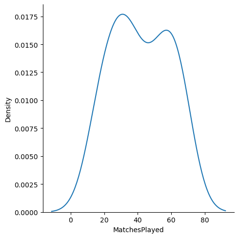

```python
# Write a code to plot the distribution of the data for the variable MatchesPlayed
sns.displot(fifa['MatchesPlayed'], kind='kde')
plt.show()
```

#### Write your Answer here:

Breaking down the code sns.displot(fifa['MatchesPlayed'], kind='kde') plt.show()

- This code calls in the Seaborn library (sns) for the distribution plot (displot)
- the kind 'kde' means a kernal density estimate which visualizes the probability density of that variable. This is used for continuous data
- the plt.show calls in the matplotlib.pyplot library to visualize the results as a graph

Breaking down the results:

- This graphs shows that there are two peaks; one at about 30 and one at about 60. This means that most of the World Cups had around those number of matches
- The graph also looks somewhat symmetrical with the data peaking at both of those two points.

## Q 11. Which country has won the world cup maximum times?

**Hint: Use value_counts() function**

`value_counts()` function returns object containing counts of unique values. The resulting object will be in descending order so that the first element is the most frequently occurring.

```python
# Write a code to find the country that has had the most wins in the World Cup

fifa['Winner'].value_counts()
```

```
Brazil        5
Italy         4
Germany FR    3
Uruguay       2
Argentina     2
England       1
France        1
Spain         1
Germany       1
Name: Winner, dtype: int64
```

#### Write your Answer here:

Breakdown the code fifa['Winner'].value_counts():

- The first part of the code fifa['Winner'] is calling the 'Winner' column from the fifa dataframe.
- The 'Winner' column contains the name of a country as categorical data
- The .value_counts() part of the code returns the count of each of the distinct values within that categorical data
- In this case, it returns the distinct counts by country to show which country has the most wins

Breakdown of the results Brazil has had the most World Cup wins in this dataset; result of 5 wins

## Q12.

### 12.1 What is the mean of the variable 'Qualified teams'?

### 12.2 What is the median of the variable 'Qualified teams'?

### 12.3 What is the mode of the variable 'Qualified teams'?

### Explain your answer

```python
# Write code to find the mea, median, and mode of 'QualifiedTeams'

m1 = fifa['QualifiedTeams'].mean()  # mean
print(m1)
m2 = fifa['QualifiedTeams'].median()  # median
print(m2)
m3 = fifa['QualifiedTeams'].mode()[0]  # mode
print(m3)
```

```
21.25
16.0
16
```

#### Write your Answer here:

Breakdown of the Code:

- The first part of the code fifa['QualifiedTeams'] calls in the column 'QualifiedTeams' from the fifa dataframe
- the .mean, .median, .mode analyzes the mean, median, mode respectively of the values within the 'QualifiedTeams' column
- This code adds an additional piece to it by creating code and assigning the results to variables
- By adding m1= before the code, Python will assign the code to the variable m1 (and so on with m2, m3). This allows the coding to reference the m1, m2, m3 in any further analysis that require the output of that code. (mean for example)
- The last part is to print the results. print (variable) will display the results

Breakdown of the results:

- Mean is 21.25
- Median is 16.0
- Mode is 16

When the mean is greater than or less than the median, it indicates that the distribution of the data is skewed.

## Q13. How many countries are above the mean level of 'Qualified Teams'?

```python
# Write a code that uses the mean from the above code to determine
# how many countries have a total number of qualified teams that is greater than the mean of  'QualifedTeams'

fifa[fifa['QualifiedTeams']>m1]['Country']
```

```
11           Spain
12          Mexico
13           Italy
14             USA
15          France
16     Korea/Japan
17         Germany
18    South Africa
19          Brazil
Name: Country, dtype: object
```

#### Write your Answer here:

Breakdown the Code fifa[fifa['QualifiedTeams']>m1]['Country']

- the first part of the code is accessing the data from the 'QualifiedTeams' column within the fifa dataframe
- The variable m1 from the code above (mean of 'QualifiedTeams') is used with the operator >. This is asking Python to find all of the values from the 'QualifiedTeams' column within the datafram fifa that have a mean value > m1 that is defined above.
- The last part of the code is asking Python to filter and display the countries with these results

Breakdown of the results:

The code above shows that the mean number of qualified teams was about 21. There are a total of 9 countries that have on average more than 21 qualified teams.

## Q14. What is the median of variables 'GoalsScored' & 'MatchesPlayed'?

Write code to find the median value of GoalsScored and MatchesPlayed. Assign variables to each of these

#### Write your Answer here:

The median Goals Scored was about 120 and the median Matches Played was 38

## Q15. Which country scored the minimum number of goals?

```python
# Write a code that finds the country that scored the minimum number of goals

fifa[fifa['GoalsScored']==fifa['GoalsScored'].min()]['Country']
```

```
0    Uruguay
1      Italy
Name: Country, dtype: object
```

#### Write your Answer here:

Breakdown of the code fifa[fifa['GoalsScored']==fifa['GoalsScored'].min()]['Country']

- The first part of the code is asking Python to use the data from the column 'GoalsScored' in the fifa dataframe to perform the second step which is finding the minimum value within the 'GoalsScored' column. The last part is to display the country with the results

Breakdown of the Results:

There are two results which means that both of these countries tied for the minimum number of goals scored.

## Q16. Plot the pairplots of 'GoalsScored', 'QualifiedTeams', 'MatchesPlayed'.

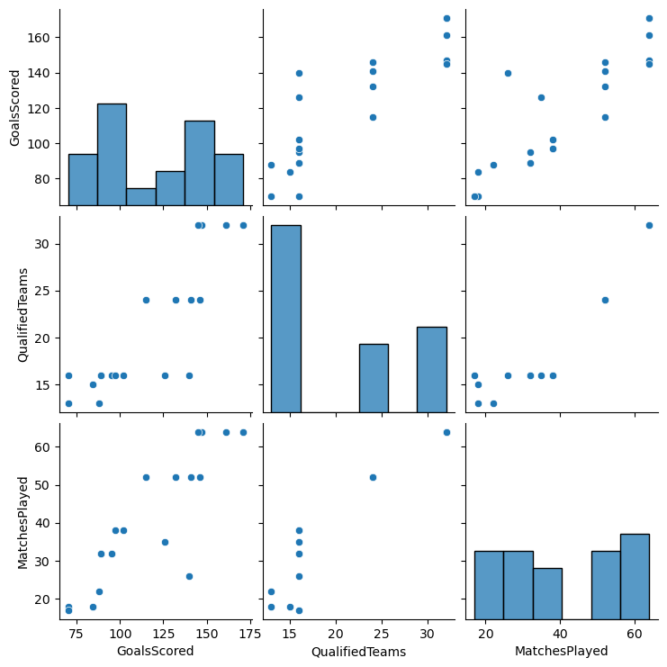

```python
# Write a code to display the pairplots of 'GoalsScored', 'QualfiedTeams', 'MatchesPlayed'

sns.pairplot(fifa[['GoalsScored', 'QualifiedTeams', 'MatchesPlayed']])
plt.show()
```

#### Write your Answer here:

Breakdown of the code sns.pairplot(fifa[['GoalsScored', 'QualifiedTeams', 'MatchesPlayed']]) plt.show()

- This code is using the pairplot within the Seaborn library (sns) visualize the relationship among these three variables.

Results of the plots: These plots help to visualize if there is a relationship between two or more of the variables. At first glance, there appears to be a positive relationship between the number of matches played and the goals scored.

## Q17. Plot the scatterplot for variables 'Country' & 'Year'.

#### Write your Answer here:

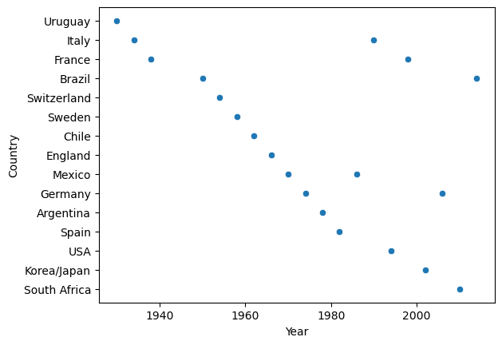

```python
# Write a code to plot 'Country' and 'Year'

sns.scatterplot(x= fifa['Year'], y= fifa['Country'])
plt.show()
```

## Q18. Plot a countplot for the variable 'Winner' to understand the number of times a country won the world cup between 1930 to 2014.

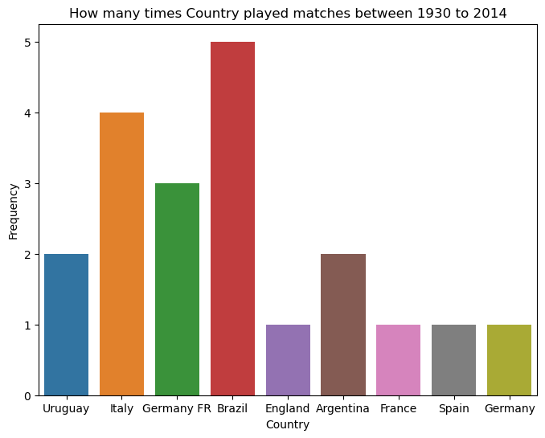

```python
# Write a code to plot how many times a country has won the Worl Cup

plt.figure(figsize=(8,6))

sns.countplot(x=fifa['Winner'])

plt.title('How many times Country played matches between 1930 to 2014')

plt.xlabel('Country')

plt.ylabel('Frequency')

plt.show()
```

#### Write your Answer here:

The analysis earlier showed that Brazil has won the most World Cups. This plot again shows that this is true. Brazil has the most wins within this dataset

## Q 19. Show boxplot and calculate the interquartile range for the variable 'GoalsScored'

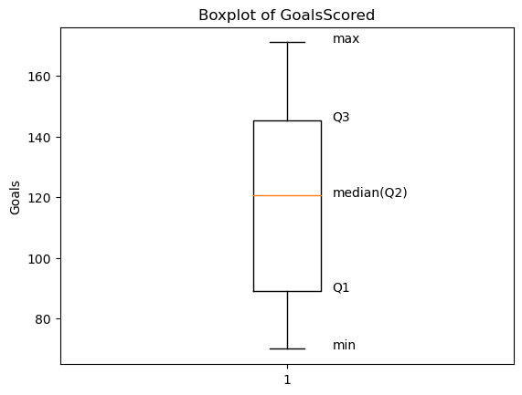

```python
# Write a code to show the boxplot and the interquartile range for 'GoalsScored'

plt.boxplot(fifa['GoalsScored'])

plt.text(x=1.1,y=fifa['GoalsScored'].min(), s='min')
plt.text(x=1.1,y=fifa.GoalsScored.quantile(0.25), s='Q1')
plt.text(x=1.1,y=fifa['GoalsScored'].median(), s='median(Q2)')
plt.text(x=1.1,y=fifa.GoalsScored.quantile(0.75), s='Q3')
plt.text(x=1.1,y=fifa['GoalsScored'].max(), s='max')

plt.title('Boxplot of GoalsScored')
plt.ylabel('Goals')
plt.show()
```

#### Write your Answer here:

```python
# Write a code to find the distance (difference) between Q3 and Q1

Q1 = fifa.quantile(0.25)
Q3 = fifa.quantile(0.75)
IQR = Q3- Q1
print(IQR)
```

```
Year              38.00
GoalsScored       56.25
QualifiedTeams    10.00
MatchesPlayed     24.50
dtype: float64
```

Breakdown of the code:

- The first part of the code is calling in the boxplot from matplotlib.pyplot. This will tell Python that this is the type of visual for the analysis
- the plt.text(....) will tell Python what labels or text to assign to the various points on the bloxplot depending on the code within that line
  - min is calling for the minimum value of the 'GoalsScored'
  - Q1 is calling for the value at the 25% percentile or quantile of the data for 'GoalsScored'
  - median is calling for the median value of the 'GoalsScored'
  - Q3 is calling for the value at the 75% percentile or quantile of the data for 'GoalsScored'
  - max is calling for the maximum value of the 'GoalsScored'

The last part of the code adds titles and labels

IQR code looks at the differnce between the numerical values of Q1 and Q3 used for the bloxplot. There is a difference of about 56 goals scored between these quandrants. This means that the number of goals scored can vary between games, some games having more goals than others.

Results of the plot: The results of this boxplot shows that there are no outliers in the dataset.

## Q 20. Find and visualize the correlation relation among numeric variables

```python
# Write a code to show the correlation between the numerical variables
corr_matrix = fifa.corr()

corr_matrix
```

|  | Year | GoalsScored | QualifiedTeams | MatchesPlayed |
| --- | --- | --- | --- | --- |
| Year | 1.000000 | 0.829886 | 0.895565 | 0.972473 |
| GoalsScored | 0.829886 | 1.000000 | 0.866201 | 0.876201 |
| QualifiedTeams | 0.895565 | 0.866201 | 1.000000 | 0.949164 |
| MatchesPlayed | 0.972473 | 0.876201 | 0.949164 | 1.000000 |

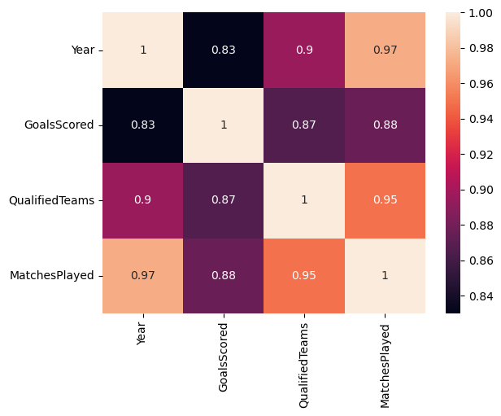

```python
# Write a code to show the correlation on a heat map
sns.heatmap(corr_matrix, annot = True)

# display the plot
plt.show()
```

#### Write your Answer here:

Breaking down the code:

The correlation matrix shows the correlation coefficient between the different variables. The coefficient is a value between -1 and 1. The closer the value is to -1 indicates a negative correlation and the closer the value is to 1 indicates a positive correlation.

Breaking down the results:

- The features with the highest correlation are the number of matches played and the year. This suggests that as the years go on, the number of matches played each year increases. Same for the number of qualified teams per year. There seems to be a strong positive relationship between the number of teams that qualify each year the longer the World Cup remains an event.

Other observations: